# MineMS2 : Mining of MS fragmentation spectra by frequent subgraph mining

Coline Gianfrotta

2024-08-01

# 1 Launching mineMS2

## 1.1 Installation

If necessary, install the package mineMS2 (from github to have the latest version):

```r
    library(devtools)
```

```r
    library(grid)
    library(gridExtra)
    library(igraph)
    library(stringr)
    #if(!require(mineMS2)) install_github("odisce/mineMS2")
    load_all()
```

```
## ℹ Loading mineMS2
```

```r
    #load_all("C:/Users/CG278150/Desktop/github_minems2/mineMS2/")
```

## 1.2 Input

The *mineMS2* package takes as input the following format mgf or may also may also take as input a list *Spectrum2* object from the *MSnbase* package.

The initial spectra reading is done using the *ms2Lib* constructor function, and the *ms2Lib* object then centralizes all the spectra information. It can take 3 kinds of inputs :

- A vector of filenames with compatible format (`mineMS2:::recognisedFormat()`)
- A single directory name in which the files in supported format are stored.
- A list containg Spectrum2 objects.

This object can also stores all the supplementary information, given by a csv file. This file should contain as much rows as spectra. By default, spectra are associated to rows in the same order, but if the dataset is composed of one spectrum by mgf file, it is possible to match each spectrum to a specific row by using a column *file*.

```r
#Finding the spectra data
path_dataset <- "../data"
path_mgf <- file.path(path_dataset, "files_champi_A.mgf")

## supplementary information about the spectra can be added, e.g. molecule name, composition
supp_infos_path <- file.path(path_dataset, "infos_champi_A.csv")
supp_infos <- read.table(supp_infos_path,header=TRUE,sep=";",encoding="utf-8", quote="")
head(supp_infos)
```

```
##   ids       mz    rt group polarity id_file     name  formula corrected_rt
## 1   1 235.0964  8.30     A      pos       1                           8.30
## 2   2 248.0914 11.37     A      pos       1                          11.42
## 3   3 251.0915 23.47     A      pos       1 Citrinin C13H14O5        23.52
## 4   4 257.1382 13.60     A      pos       1                          13.60
## 5   5 334.2274 15.85     A      pos       1                          15.85
## 6   6 335.2187 36.25     A      pos       1                          36.25
```

```r
current_dir <- getwd()
setwd(path_dataset)

### Spectra are read with supplementary information
m2l <- ms2Lib(path_mgf, suppInfos = supp_infos)
```

```
## Reading MGF file ../data/files_champi_A.mgf.
```

```r
m2l
```

```
## An ms2Lib object containing 52 spectra.
## The available supplementary informations are: mz.precursor file title ids mz rt group polarity id_file Name formula corrected_rt N
## It contains:  0 patterns
```

These supplementary information may also be used to generate an ID for each spectra, which can be used in the functions of the *mineMS2* software, and which is reused into the visualisation. Here fore examples we design an ID composed of the mass and the retention time for the precursor for each spectrum. Initially, this ID is set to S1,S2,…,SN where N is the number of spectra.

```r
infos <- getInfo(m2l,"S")
ids <- paste(paste("mz",infos[,"mz"],sep=""),paste("rt",infos[,"rt"],sep=""),sep="_")
m2l <- setIds(m2l,ids)
```

This ID is notably used in the visualisation offered by the *mineMS2* package.

Any extracted spectrum may be plot using the *plot* function of the *msnBase* package, using its *id* :

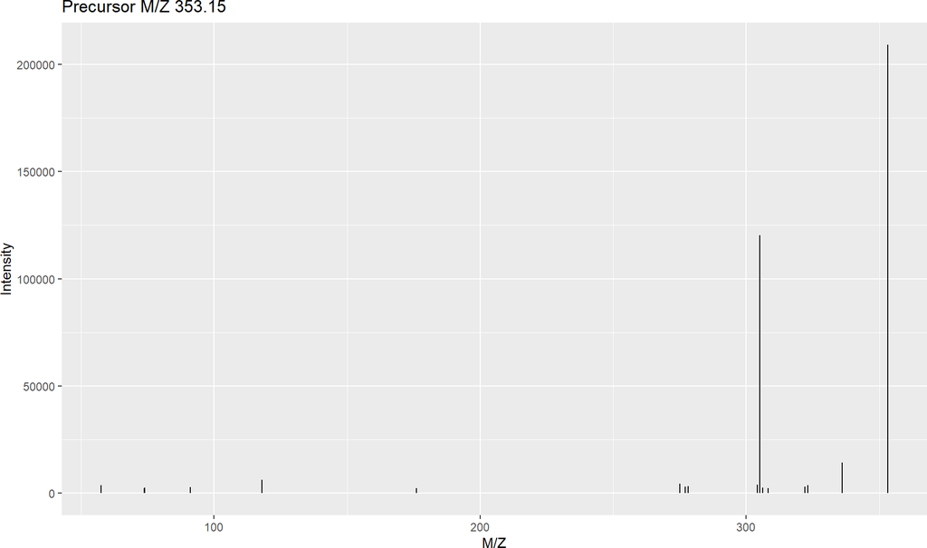

```r
plot(m2l,"S10")
```

Here the “S10” index correspond to the 10th spectra. These indexes will be discussed later.

## 1.3 Mass differences discretization

The first step of *mineMS2* algorithm is to compute all mass differences and discretize them. The algorithm uses the method of kernel density estimation, with a gaussian kernel (ref), for the discretization. It uses a density function with a varying bandwidth to take into account the fact that the mass accuracy of mass spectrometers are in ppm.

This step is very important, as it determines the initial set of graphs. The most important parameters and their meaning are listed here :

- *ppm*: The accuracy of the mass spectrometer in ppm used to determine the bandwidth of the density.
- *dmz*: The minimum deviation use for bandwidth in dalton.
- *count*: The minimum number of spectra in which a loss needs to be present.
- *precPpm*: The ppm tolerance used to match the precursor.
- *precDmz*: The minimum tolerance used to match the precursor.
- *maxFrags*: only the *maxFrags* most intense peaks will be considered to build the graph (shoul be at most 20, to be done in reasonable time).
- *atoms* : list of possible atoms for formula generation, along with their respective maximum number (example: `list("C"=50,"H"=100,"N"=6,"O"=6,"S"=2,"Cl"=1,"P"=2)`)
- *heteroAtoms*: Shall hetero atoms (*P*,*S*,*Cl*) be used when generating formula for mass differences.
- *limMzFormula*: the range of mass difference values for which formulas will be searched. Higher values will be considered as too high to find a set of formula without ambiguity. They are however kept as mass differences.

The *precPpm* and *precDmz* arguments are used to find a peak corresponding to the precursor on the MS-MS spectra. If it is not present an artificial peak is added. For each mass difference in the range defined by the argument *limMzFormula*, possible formulas are generated, using a decomposition of possible atoms given by the argument *atoms*. If no formula is found, the mass difference is discarded.

Default values are set for every parameters.

```r
m2l <- discretizeMassLosses(m2l,
                            ppm=15,
                            dmz=0.007,
                            count=2,
                                          precPpm=20,
                            precDmz=0.02,
                            maxFrags=15,
                            heteroAtoms = TRUE,
                            limMzFormula = c(14.5, 200))
```

After this step, the list of discretized mass differences labels may be extracted.

```r
head(lossesTable(m2l))
```

```
##   lab       mz    mzmin    mzmax count formula
## 1   1 16.03131 16.02665 16.03598     4     CH4
## 2   2 17.02676 17.02209 17.03143    24     H3N
## 3   3 18.01067 18.00600 18.01533    38     H2O
## 4   4 24.00014 23.99547 24.00481     3      C2
## 5   5 26.01574 26.01107 26.02041     3    C2H2
## 6   6 28.03127 28.02661 28.03594     6    C2H4
```

Each row of this table corresponds to one discretized mass difference, with: * the mean value (mz) * the minimum value (mzmin) * the maximum value (mzmax) * the number of mass differences in it (count) * the possible formula(s) if calculated (formula)

The step of discretization also constructs the directed acyclic graphs (DAGs) corresponding to the spectra, with vertices as peaks and directed edges as discretized mass differences. Each DAG can be plotted, in a static (*tkplot* argument to FALSE) or a dynamic way (*tkplot* argument to TRUE).

```r
plot(m2l, "D10", tkplot=TRUE)
```

The graph *D10* corresponds to the spectrum *S10*.

## 1.4 Mining frequent subgraphs

The next step is to generate the frequent subgraphs among the DAGs. To do so, we will use the *mineClosedSubgraphs* function, that implements the FSM algorithm. Two important parameters are the *count* parameter which is the minimum number of occurrences of a pattern, and the *sizeMin* parameter which determines the minimum size of the mined graphs. Here we set *sizeMin* to 1 to mine single mass differences.

```r
m2l <- mineClosedSubgraphs(m2l,count=2,sizeMin = 1)
```

```
## Processing finished, 97 patterns mined.
```

```r
setwd(current_dir)
```

This step can be quite time consuming.

## 1.5 Select information from the *ms2Lib* object

The *ms2Lib* object includes 3 different data types that can be queried using their *id* (which includes a prefix specifying the data type and a number): * the spectra (S) * the patterns (P) * the mass differences (L) Further information on the functionality of these package is given in the next subsection.

### 1.5.1 Spectra

Spectra may be queried using id starting by “S”. It is possible to find a specific spectra by using the *findMz* function, with the “S” parameter. In this example, it searches for spectra with precursor mz values close to 147.0, with certain values of tolerance. It returns the *ids* of the spectra if it is found, or an empty vector if not.

```r
sid <- findMz(m2l,147.0,type="S",ppm=8,dmz=0.2)
sid
```

```
## [1] "S19"
```

Information about the spectra may be queried using the *getInfo* function :

```r
getInfo(m2l,sid)
```

```
##     mz.precursor                       file ids       mz   rt group polarity
## S19     147.0648 ../data/files_champi_A.mgf  19 147.0639 3.09     A      pos
##     id_file       Name formula corrected_rt  N
## S19       2 Verrucolon    <NA>         3.09 19
```

The patterns in which the spectra are present may be extracted using the the *select* function :

```r
pids <- select(m2l,sid,"P")
pids
```

```
## $S19
##  [1] "P17" "P18" "P19" "P20" "P21" "P22" "P23" "P24" "P25" "P26" "P27" "P29"
## [13] "P30" "P31" "P32" "P36" "P42" "P43" "P44" "P45" "P46" "P47" "P48" "P51"
## [25] "P52" "P58" "P63" "P64" "P65" "P68" "P69"
```

## 1.6 Mass differences

Mass differences *ids* start by the *L* letter. They can be searched using the *findMz* function too. Some information may be extracted using the *getInfo* function. We don’t demonstrate it as they are similar to those of spectra. They can be searched against patterns (*P*) or DAGs (*D*) using the *select* function :

```r
##Finding a mass difference corresponding to phenyalanine
lphenyl <- findMz(m2l,type = "L",147.05,dmz = 0.1)
pids <- select(m2l,lphenyl,"P")
pids
```

```
## $L73
## [1] "P33" "P37" "P38" "P86" "P87" "P90"
```